# Insights and visualization only

# **Granualar look at the "deaths" recorded worldwide during january to july**

```python
covid_deaths.dtypes
```

```
Country/Region    object
Province/State    object
Date              object
Deaths             int64
dtype: object
```

```python
covid_deaths['Date'] = pd.to_datetime(covid_deaths['Date'])
```

```python
covid_deaths['Date']
```

```
0       2020-01-22
1       2020-01-23
2       2020-01-24
3       2020-01-25
4       2020-01-26
           ...
46279   2020-03-12
46280   2020-04-12
46281   2020-05-12
46282   2020-06-12
46283   2020-07-12
Name: Date, Length: 46284, dtype: datetime64[ns]
```

```
Date
2020-01-31         889
2020-02-29       46910
2020-03-31      397845
2020-04-30     4311641
2020-05-31     9610078
2020-06-30    13310325
2020-07-31     7083171
Freq: M, Name: Deaths, dtype: int64
```

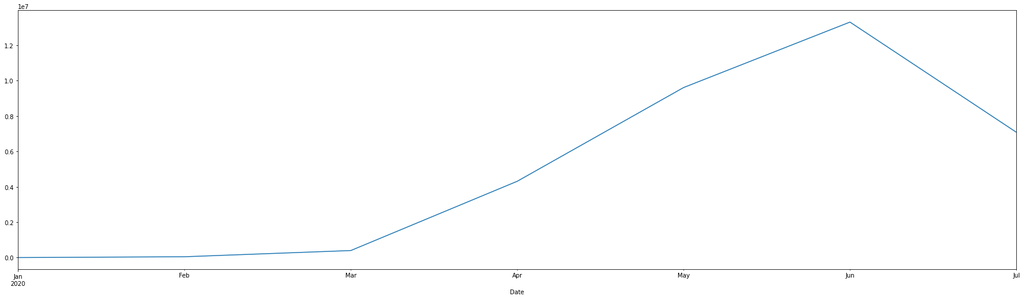

```python
Daily_deaths=covid_deaths.groupby(pd.Grouper(key='Date', freq='M')).sum()['Deaths']
Daily_deaths.plot(kind="line",figsize=(30,8))
print(Daily_deaths)
```

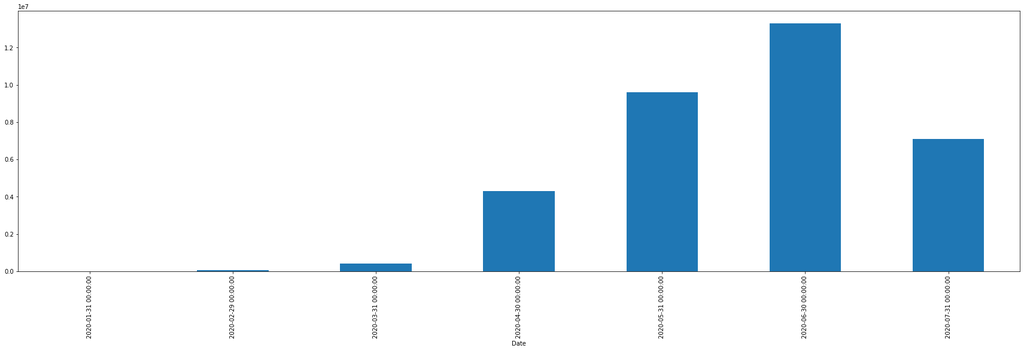

```python
Daily_deaths=covid_deaths.groupby(pd.Grouper(key='Date', freq='M')).sum()['Deaths']
Daily_deaths.plot(kind="bar",figsize=(30,8))
```

```
Date
2020-01-31         889
2020-02-29       46910
2020-03-31      397845
2020-04-30     4311641
2020-05-31     9610078
2020-06-30    13310325
2020-07-31     7083171
Freq: M, Name: Deaths, dtype: int64
```

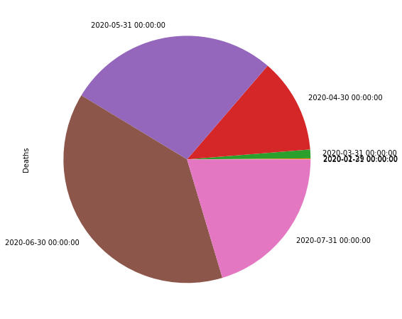

```python
Daily_deaths=covid_deaths.groupby(pd.Grouper(key='Date', freq='M')).sum()['Deaths']
Daily_deaths.plot(kind="pie",figsize=(30,8))
print(Daily_deaths)
```

## **How well is the "recovery" of the victims?, lets have a look at it!**

```python
covid_recovered.dtypes
```

```
Country/Region    object
Province/State    object
Date              object
Recovered          int64
dtype: object
```

```python
covid_recovered['Date'] = pd.to_datetime(covid_recovered['Date'])
```

```python
covid_recovered['Date']
```

```
0       2020-01-22
1       2020-01-23
2       2020-01-24
3       2020-01-25
4       2020-01-26
           ...
44017   2020-03-12
44018   2020-04-12
44019   2020-05-12
44020   2020-06-12
44021   2020-07-12
Name: Date, Length: 44022, dtype: datetime64[ns]
```

# **Due to the improved medication techniques given by the doctors to the victims of covid-19,has given the hope of good number for the recovery of patients on planet Earth**

```
Date
2020-01-31          844
2020-02-29       380794
2020-03-31      2705181
2020-04-30     16306649
2020-05-31     54096081
2020-06-30    118881788
2020-07-31     83680717
Freq: M, Name: Recovered, dtype: int64
```

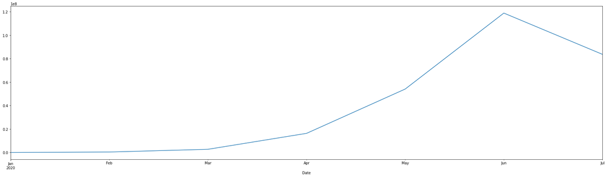

```python
recoverey_line=covid_recovered.groupby(pd.Grouper(key='Date', freq='M')).sum()['Recovered']
recoverey_line.plot(kind="line",figsize=(30,8))
print(recoverey_line)
```

```
Date
2020-01-31          844
2020-02-29       380794
2020-03-31      2705181
2020-04-30     16306649
2020-05-31     54096081
2020-06-30    118881788
2020-07-31     83680717
Freq: M, Name: Recovered, dtype: int64
```

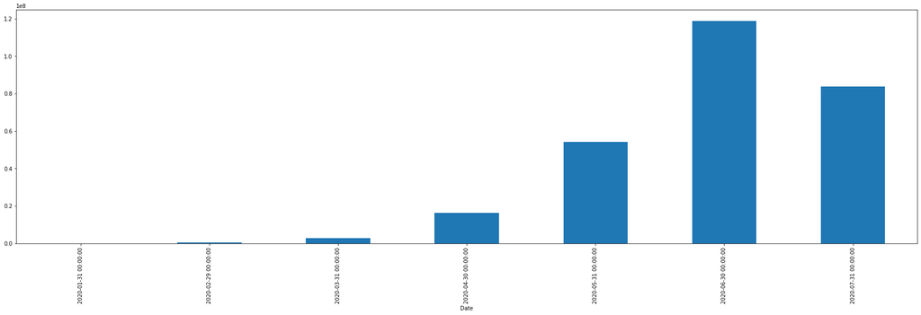

```python
recoverey_bar=covid_recovered.groupby(pd.Grouper(key='Date', freq='M')).sum()['Recovered']
recoverey_bar.plot(kind="bar",figsize=(30,8))
print(recoverey_bar)
```

```
Date
2020-01-31          844
2020-02-29       380794
2020-03-31      2705181
2020-04-30     16306649
2020-05-31     54096081
2020-06-30    118881788
2020-07-31     83680717
Freq: M, Name: Recovered, dtype: int64
```

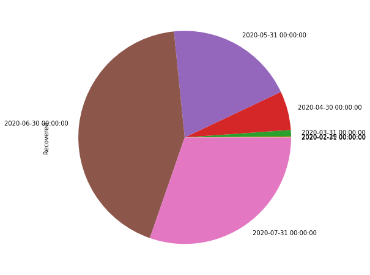

```python
recoverey_pie=covid_recovered.groupby(pd.Grouper(key='Date', freq='M')).sum()['Recovered']
recoverey_pie.plot(kind="pie",figsize=(30,8))
print(recoverey_pie)
```

```python
covid_confirmed.shape
```

```
(46284, 4)
```

```python
covid_deaths.shape
```

```
(46284, 4)
```

```python
covid_recovered.shape
```

```
(44022, 4)
```

```python
covid_confirmed.tail()
```

|  | Country/Region | Province/State | Date | confirmed |
| --- | --- | --- | --- | --- |
| 46279 | Zimbabwe | NaN | 2020-03-12 | 0 |
| 46280 | Zimbabwe | NaN | 2020-04-12 | 14 |
| 46281 | Zimbabwe | NaN | 2020-05-12 | 36 |
| 46282 | Zimbabwe | NaN | 2020-06-12 | 343 |
| 46283 | Zimbabwe | NaN | 2020-07-12 | 985 |

```python
c=sum(covid_confirmed['confirmed'])
print(c)
```

```
619204759
```

```python
covid_deaths.tail()
```

|  | Country/Region | Province/State | Date | Deaths |
| --- | --- | --- | --- | --- |
| 46279 | Zimbabwe | NaN | 2020-03-12 | 0 |
| 46280 | Zimbabwe | NaN | 2020-04-12 | 3 |
| 46281 | Zimbabwe | NaN | 2020-05-12 | 4 |
| 46282 | Zimbabwe | NaN | 2020-06-12 | 4 |
| 46283 | Zimbabwe | NaN | 2020-07-12 | 18 |

```python
d=sum(covid_deaths['Deaths'])
print(d)
```

```
34760859
```

```python
covid_recovered.tail()
```

|  | Country/Region | Province/State | Date | Recovered |
| --- | --- | --- | --- | --- |
| 44017 | Zimbabwe | NaN | 2020-03-12 | 0 |
| 44018 | Zimbabwe | NaN | 2020-04-12 | 0 |
| 44019 | Zimbabwe | NaN | 2020-05-12 | 9 |
| 44020 | Zimbabwe | NaN | 2020-06-12 | 51 |
| 44021 | Zimbabwe | NaN | 2020-07-12 | 328 |

```python
r=sum(covid_recovered['Recovered'])
print(r)
```

```
276052054
```

```python
covid_recovered.isnull().sum()
```

```
Country/Region        0
Province/State    32364
Date                  0
Recovered             0
dtype: int64
```

```python
countrywise_data.head()
```

|  | FIPS | Admin2 | Province_State | Country_Region | Last_Update | Lat | Long_ | Confirmed | Deaths | Recovered | Active | Combined_Key | Incidence_Rate | Case-Fatality_Ratio |
| --- | --- | --- | --- | --- | --- | --- | --- | --- | --- | --- | --- | --- | --- | --- |
| 0 | 45001.0 | Abbeville | South Carolina | US | 2020-07-13 04:43:04 | 34.223334 | -82.461707 | 153 | 1 | 0 | 152.0 | Abbeville, South Carolina, US | 623.802340 | 0.653595 |
| 1 | 22001.0 | Acadia | Louisiana | US | 2020-07-13 04:43:04 | 30.295065 | -92.414197 | 1339 | 45 | 0 | 1294.0 | Acadia, Louisiana, US | 2158.111048 | 3.360717 |
| 2 | 51001.0 | Accomack | Virginia | US | 2020-07-13 04:43:04 | 37.767072 | -75.632346 | 1042 | 14 | 0 | 1028.0 | Accomack, Virginia, US | 3224.408962 | 1.343570 |
| 3 | 16001.0 | Ada | Idaho | US | 2020-07-13 04:43:04 | 43.452658 | -116.241552 | 4146 | 25 | 0 | 4121.0 | Ada, Idaho, US | 860.903637 | 0.602991 |
| 4 | 19001.0 | Adair | Iowa | US | 2020-07-13 04:43:04 | 41.330756 | -94.471059 | 17 | 0 | 0 | 17.0 | Adair, Iowa, US | 237.695749 | 0.000000 |

```python
countrywise_data.isnull().sum()
```

```
FIPS                   682
Admin2                 678
Province_State         169
Country_Region           0
Last_Update              0
Lat                     74
Long_                   74
Confirmed                0
Deaths                   0
Recovered                0
Active                   4
Combined_Key             0
Incidence_Rate          74
Case-Fatality_Ratio     51
dtype: int64
```

## The proportion of deaths from a certain disease compared to the total number of people diagnosed with the disease for a particular period is CFR

```
Country_Region
Afghanistan            2.931700
Albania                2.692530
Algeria                5.266997
Andorra                6.081871
Angola                 5.138340
                        ...
West Bank and Gaza     0.577849
Western Sahara        10.000000
Yemen                 28.464164
Zambia                 2.216359
Zimbabwe               1.827411
Name: Case-Fatality_Ratio, Length: 188, dtype: float64
```

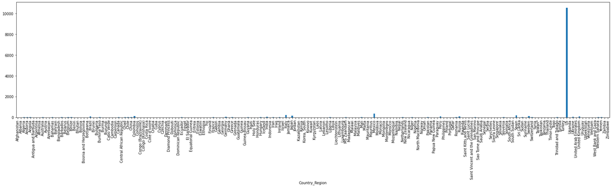

```python
CFR=countrywise_data.groupby('Country_Region').sum()['Case-Fatality_Ratio']
CFR.plot(kind="bar",figsize=(30,6))
print(CFR)
```